# Lab 3: CART for Loan Delinquency

Bright Joses

2026-11-19

# Part 1: Reproduce the CART model from the Topic 3 demonstration

## Data preparation (as in the demo)

```r
loandata <- read.csv("Loan_Delinquent_Dataset.csv")
for (v in c("isDelinquent", "term", "gender", "purpose", "home_ownership", "age", "FICO"))
  loandata[[v]] <- as.factor(loandata[[v]])
loandata <- loandata[, -1]                                   # drop ID
levels(loandata$purpose) <- c("Car", "House", "Medical", "Other", "Other",
                              "Personal", "Wedding")          # merge 'Other'/'other'

set.seed(1000)                                                # same seed as the demo
sample <- sample.split(loandata$isDelinquent, SplitRatio = 0.7)
train <- subset(loandata, sample == TRUE)
test  <- subset(loandata, sample == FALSE)
c(train = nrow(train), test = nrow(test))
```

```
## train  test
##  8084  3464
```

```r
prop.table(table(train$isDelinquent))
```

```
##
##         0         1
## 0.3313953 0.6686047
```

The positive class throughout is **isDelinquent = 1**. A *false negative* is a delinquent borrower the model lets through (predicts 0); a *false positive* is a good borrower the model flags (predicts 1).

## The demo’s CART model (Model 2)

```r
r.ctrl2 <- rpart.control(minsplit = 500, minbucket = 150, cp = 0, xval = 10)
model2 <- rpart(isDelinquent ~ ., data = train, method = "class", control = r.ctrl2)
model2
```

```
## n= 8084
##
## node), split, n, loss, yval, (yprob)
##       * denotes terminal node
##
##  1) root 8084 2679 1 (0.33139535 0.66860465)
##    2) FICO=>500 3633 1589 0 (0.56262042 0.43737958)
##      4) gender=Female 1687  393 0 (0.76704209 0.23295791) *
##      5) gender=Male 1946  750 1 (0.38540596 0.61459404)
##       10) age=20-25 678  332 0 (0.51032448 0.48967552)
##         20) term=36 months 444  134 0 (0.69819820 0.30180180) *
##         21) term=60 months 234   36 1 (0.15384615 0.84615385) *
##       11) age=>25 1268  404 1 (0.31861199 0.68138801)
##         22) term=60 months 178    0 0 (1.00000000 0.00000000) *
##         23) term=36 months 1090  226 1 (0.20733945 0.79266055) *
##    3) FICO=300-500 4451  635 1 (0.14266457 0.85733543)
##      6) term=60 months 232    0 0 (1.00000000 0.00000000) *
##      7) term=36 months 4219  403 1 (0.09552027 0.90447973) *
```

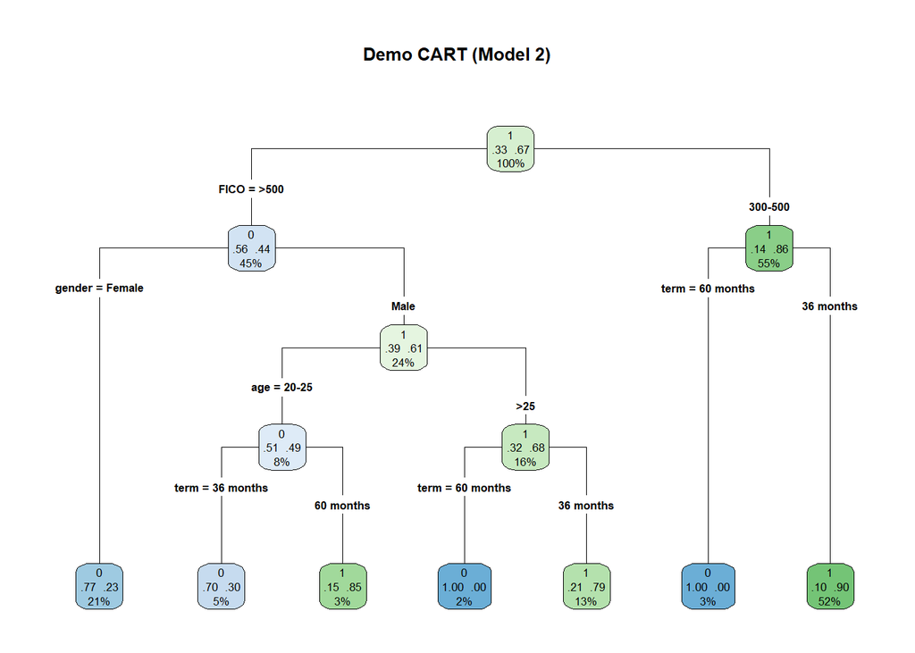

```r
rpart.plot(model2, type = 4, extra = 104, main = "Demo CART (Model 2)")
```

## A deliberately over-grown tree

The demo’s tree has few leaves because the controls (`minsplit = 500`) stop it early. To see what pruning does, I also grow a maximal tree (every split allowed, `cp = -1`) and prune it back in Part 2.

```r
set.seed(1000)
full <- rpart(isDelinquent ~ ., data = train, method = "class",
              control = rpart.control(minsplit = 2, minbucket = 1, cp = -1, xval = 10))
n_leaves <- function(m) sum(m$frame$var == "<leaf>")
n_leaves(full)
```

```
## [1] 111
```

# Part 2: Prune using the cross-validated results

```r
printcp(full)
```

```
##
## Classification tree:
## rpart(formula = isDelinquent ~ ., data = train, method = "class",
##     control = rpart.control(minsplit = 2, minbucket = 1, cp = -1,
##         xval = 10))
##
## Variables actually used in tree construction:
## [1] age            FICO           gender         home_ownership purpose
## [6] term
##
## Root node error: 2679/8084 = 0.3314
##
## n= 8084
##
##            CP nsplit rel error  xerror     xstd
## 1  1.6984e-01      0   1.00000 1.00000 0.015798
## 2  1.6648e-01      1   0.83016 0.84882 0.015090
## 3  8.6599e-02      2   0.66368 0.66368 0.013901
## 4  4.4046e-02      3   0.57708 0.57708 0.013199
## 5  9.3318e-05      6   0.44494 0.44494 0.011899
## 6  0.0000e+00     10   0.44457 0.45241 0.011981
## 7 -1.0000e+00    110   0.44457 0.45241 0.011981
```

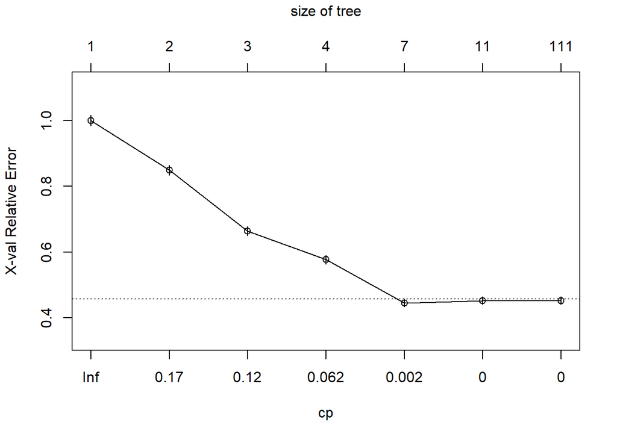

```r
plotcp(full)
```

```r
tb <- full$cptable
best_row <- which.min(tb[, "xerror"])
best_cp  <- tb[best_row, "CP"]
one_se   <- tb[best_row, "xerror"] + tb[best_row, "xstd"]
row_1se  <- min(which(tb[, "xerror"] <= one_se))
c(best_row = best_row, best_cp = best_cp, nsplit = tb[best_row, "nsplit"],
  min_xerror = tb[best_row, "xerror"], row_1se = row_1se)
```

```
##   best_row.5      best_cp       nsplit   min_xerror      row_1se
## 5.0000000000 0.0000933184 6.0000000000 0.4449421426 5.0000000000
```

```r
pruned <- prune(full, cp = best_cp)
n_leaves(pruned)
```

```
## [1] 7
```

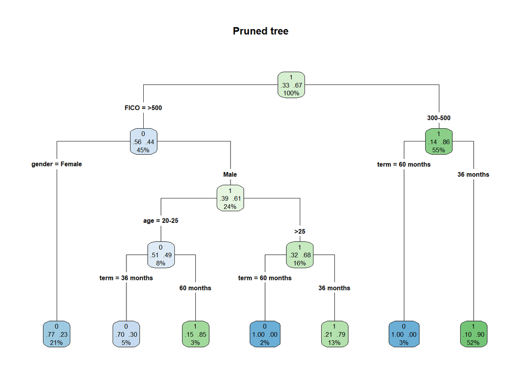

```r
rpart.plot(pruned, type = 4, extra = 104, main = "Pruned tree")
```

**Chosen cp = 0.000093.** The cross-validated error (`xerror`) falls from 1.00 with no splits to 0.445 at 6 splits, then stops improving and creeps back up (0.452) as more splits are allowed. I took the row with the lowest `xerror`; the one-standard-error rule picks the same row (row 5), so there is no ambiguity. Pruning at this cp shrinks the tree from 111 leaves to 7, and any cp between 0.000093 and 0.044 gives the same tree. It uses only `FICO`, `gender`, `age` and `term`; `purpose` and `home_ownership` never help.

# Part 3: Evaluate the pruned tree on the test data

```r
p_test  <- predict(pruned, test)[, "1"]          # P(delinquent)
actual  <- test$isDelinquent
make_tab <- function(p, cutoff) {
  pred <- factor(as.integer(p > cutoff), levels = 0:1)
  table(Actual = factor(actual, levels = 0:1), Predicted = pred)
}
metrics <- function(tab) {
  c(accuracy    = sum(diag(tab)) / sum(tab),
    sensitivity = tab["1", "1"] / sum(tab["1", ]),   # delinquents caught
    specificity = tab["0", "0"] / sum(tab["0", ]))   # good borrowers passed
}

tab50 <- make_tab(p_test, 0.5)
tab50
```

```
##       Predicted
## Actual    0    1
##      0  830  318
##      1  211 2105
```

```r
round(metrics(tab50), 4)
```

```
##    accuracy sensitivity specificity
##      0.8473      0.9089      0.7230
```

Sensitivity is the share of delinquent borrowers the tree flags; specificity is the share of good borrowers it correctly lets through.

## ROC curve and AUC

```r
roc_at <- function(cutoff) {
  tab <- make_tab(p_test, cutoff)
  c(cutoff = cutoff, TPR = tab["1", "1"] / sum(tab["1", ]),
    FPR = tab["0", "1"] / sum(tab["0", ]))
}
cuts <- c(-Inf, sort(unique(p_test)), Inf)
roc <- as.data.frame(t(sapply(cuts, function(ct) {
  pred <- as.integer(p_test >= ct)             # flag everyone at or above the score
  c(cutoff = ct,
    TPR = sum(pred == 1 & actual == 1) / sum(actual == 1),
    FPR = sum(pred == 1 & actual == 0) / sum(actual == 0))
})))
roc <- roc[order(roc$FPR, roc$TPR), ]

# AUC = P(random delinquent scores higher than random good borrower), ties = 1/2
auc <- function(score, y) {
  r <- rank(score); n1 <- sum(y == 1); n0 <- sum(y == 0)
  (sum(r[y == 1]) - n1 * (n1 + 1) / 2) / (n1 * n0)
}
AUC <- auc(p_test, as.integer(as.character(actual)))
AUC
```

```
## [1] 0.8437459
```

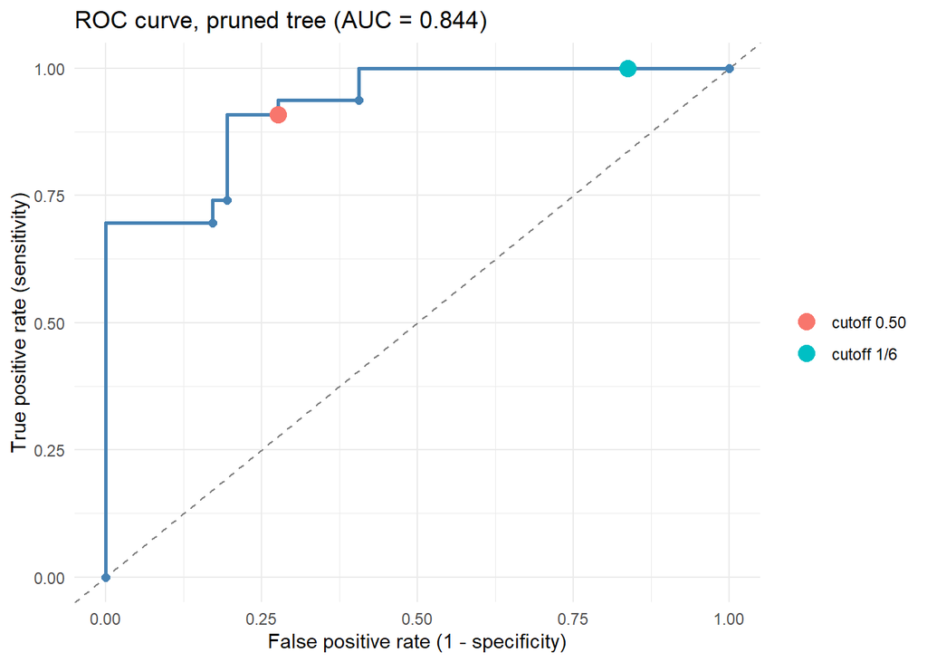

```r
n_distinct_scores <- length(unique(p_test))

r50 <- roc_at(0.5); r16 <- roc_at(1/6)
pt <- data.frame(label = c("cutoff 0.50", "cutoff 1/6"),
                 TPR = c(r50[["TPR"]], r16[["TPR"]]),
                 FPR = c(r50[["FPR"]], r16[["FPR"]]))
ggplot(roc, aes(FPR, TPR)) +
  geom_abline(linetype = "dashed", colour = "grey50") +
  geom_step(colour = "steelblue", linewidth = 1, direction = "vh") +
  geom_point(data = roc, colour = "steelblue", size = 2) +
  geom_point(data = pt, aes(colour = label), size = 4) +
  labs(title = paste0("ROC curve, pruned tree (AUC = ", round(AUC, 3), ")"),
       x = "False positive rate (1 - specificity)",
       y = "True positive rate (sensitivity)", colour = "") +
  theme_minimal()
```

# Part 4: Business-rule memo

```r
rpart.rules(pruned, cover = TRUE)
```

```
##  isDelinquent                                                                              cover
##          0.00 when FICO is    >500 & term is 60 months & gender is   Male & age is   >25      2%
##          0.00 when FICO is 300-500 & term is 60 months                                        3%
##          0.23 when FICO is    >500                     & gender is Female                    21%
##          0.30 when FICO is    >500 & term is 36 months & gender is   Male & age is 20-25      5%
##          0.79 when FICO is    >500 & term is 36 months & gender is   Male & age is   >25     13%
##          0.85 when FICO is    >500 & term is 60 months & gender is   Male & age is 20-25      3%
##          0.90 when FICO is 300-500 & term is 36 months                                       52%
```

> **Memo to loan officers** (rules from the pruned tree; share of past loans in brackets)
> 1. FICO 500 or below, 36-month term: **decline**. 90% went delinquent [52%].
> 2. FICO 500 or below, 60-month term: approve. None went delinquent [3%].
> 3. FICO above 500, female: approve. 23% delinquent [21%].
> 4. FICO above 500, male: a 36-month loan is risky if over 25 (79% delinquent) but acceptable at 20-25 (30%). A 60-month loan is risky at 20-25 (85%) and safe over 25 (none).

> **Caution:** the 60-month results are surprising, so check them. Gender and age drive rules 3 and 4, and lending law in many places forbids using them, so get legal review before use.

*Memo length: 113 words (limit 150).*

# Written answers

## 1. What do the errors cost?

At the 0.5 cutoff the test set has **211 false negatives** and **318 false positives**.

- **False negative (a delinquent borrower approved):** the lender loses the unrecovered principal and the cost of collections, and the loan adds to bad debt. The borrower is also harmed, because they take on debt they cannot repay.
- **False positive (a good borrower declined):** the borrower loses a loan they would have repaid, such as a house, car or medical need, and may turn to worse credit. The lender loses the interest and fee income that loan would have earned.

I would rather reduce **false negatives**. One missed delinquency usually costs the lender a large part of the principal, while a wrongly declined loan costs only the margin, so in money terms a false negative is the more expensive error. The price is more false positives, so how far to push depends on the cost ratio (next question). Declining good borrowers also has a fairness cost, so it should not be ignored.

## 2. If a miss costs five times a wrong decline

Approving a borrower with delinquency probability $p$ has expected cost $5p$ (a miss); declining has expected cost $1\times(1-p)$ (a wrong decline). Decline whenever $5p > 1-p$, that is $p > 1/6 \approx 0.167$. In general the threshold is $C_{FP}/(C_{FP}+C_{FN}) = 1/(1+5)$.

```r
tab_c <- make_tab(p_test, 1/6)
tab_c
```

```
##       Predicted
## Actual    0    1
##      0  186  962
##      1    0 2316
```

```r
cmp <- rbind(`cutoff 0.50` = metrics(tab50), `cutoff 1/6` = metrics(tab_c))
cost <- function(tab) 5 * tab["1", "0"] + 1 * tab["0", "1"]
cmp <- cbind(round(cmp, 4), FN = c(tab50["1", "0"], tab_c["1", "0"]),
             FP = c(tab50["0", "1"], tab_c["0", "1"]),
             total_cost = c(cost(tab50), cost(tab_c)))
cmp
```

```
##             accuracy sensitivity specificity  FN  FP total_cost
## cutoff 0.50   0.8473      0.9089       0.723 211 318       1373
## cutoff 1/6    0.7223      1.0000       0.162   0 962        962
```

At the 1/6 cutoff sensitivity moves from 0.909 to 1 and specificity from 0.723 to 0.162. The total cost (in units of one wrongly declined loan) goes from 1373 to 962, a change of -29.9%. The tree has only 6 distinct scores, so moving the cutoff from 0.5 to 1/6 changes which leaves are flagged, and changes accuracy (0.847 to 0.722), but it cannot change anything in between.

## 3. What does the ROC curve show?

A confusion matrix is one point: it fixes a single cutoff. The ROC curve shows sensitivity against the false-positive rate at **every** cutoff, so it shows the whole trade-off and lets you choose a cutoff after the costs are known. It also does not depend on class balance.

**AUC = 0.844.** As a probability: if I pick one delinquent and one non-delinquent borrower at random from the test set, there is a 84.4% chance the tree gives the delinquent borrower the higher risk score (ties count half). 0.5 is a coin flip and 1 is perfect.

A tree gives so few points because every borrower who lands in the same leaf gets the same score (the leaf’s class proportion). This tree has 7 leaves but only 6 distinct scores, so the ROC curve has only 7 corners instead of a smooth curve. Many ties also mean the tree cannot rank borrowers inside a leaf.

## 4. Full tree vs pruned tree

```r
acc <- function(m, dat) mean(predict(m, dat, type = "class") == dat$isDelinquent)
gap <- data.frame(
  Tree = c("Full (maximal)", "Pruned"),
  Leaves = c(n_leaves(full), n_leaves(pruned)),
  Train_accuracy = round(c(acc(full, train), acc(pruned, train)), 4),
  Test_accuracy = round(c(acc(full, test), acc(pruned, test)), 4))
gap$Gap_train_minus_test <- gap$Train_accuracy - gap$Test_accuracy
gap
```

```
##             Tree Leaves Train_accuracy Test_accuracy Gap_train_minus_test
## 1 Full (maximal)    111         0.8527        0.8470               0.0057
## 2         Pruned      7         0.8525        0.8473               0.0052
```

The full tree has 111 leaves and scores 85.27% on training data against 84.7% on test data, a gap of 0.57 points. The pruned tree has 7 leaves and scores 85.25% against 84.73%, a gap of 0.53 points. So here pruning removes 104 leaves without losing accuracy. The gap is small in both cases because the data has only six categorical predictors with few distinct combinations, so there is little noise for a tree to memorise. The over-grown tree is still not better, only bigger and harder to explain.

**What cp controls:** `cp` is the complexity penalty. A split is kept only if it lowers the tree’s error by at least `cp` times the root error, so a larger cp gives a smaller tree, and `cp = 0` allows any split. **What `xerror` says:** it is the 10-fold cross-validated error, relative to the root (one-leaf) tree, so 0.445 means the tree makes 44.5% as many mistakes as always guessing the majority class. `xstd` is its standard error. The `xerror` falls until about 6 splits and then flattens and rises, which is the sign that further splits only fit noise, and I prune where it is lowest.

## 5. Instability: would the rules change on different data?

I refit the whole procedure (grow the maximal tree, choose cp by cross-validated error, prune) on 100 bootstrap resamples of the training data, and on 100 random samples of only 1,000 loans.

```r
refit <- function(dat) {
  m <- rpart(isDelinquent ~ ., data = dat, method = "class",
             control = rpart.control(minsplit = 2, minbucket = 1, cp = -1, xval = 10))
  t <- m$cptable
  p <- prune(m, cp = t[which.min(t[, "xerror"]), "CP"])
  vars <- sort(unique(as.character(p$frame$var[p$frame$var != "<leaf>"])))
  list(root = as.character(p$frame$var[1]),
       vars = paste(vars, collapse = "+"),
       leaves = sum(p$frame$var == "<leaf>"),
       test_acc = mean(predict(p, test, type = "class") == test$isDelinquent))
}
summarise_runs <- function(res) {
  data.frame(
    root_FICO_pct = 100 * mean(sapply(res, `[[`, "root") == "FICO"),
    same_4_vars_pct = 100 * mean(sapply(res, `[[`, "vars") == "age+FICO+gender+term"),
    core_always_pct = 100 * mean(grepl("age", sapply(res, `[[`, "vars")) &
                                 grepl("FICO", sapply(res, `[[`, "vars")) &
                                 grepl("gender", sapply(res, `[[`, "vars")) &
                                 grepl("term", sapply(res, `[[`, "vars"))),
    distinct_variable_sets = length(unique(sapply(res, `[[`, "vars"))),
    exactly_7_leaves_pct = 100 * mean(sapply(res, `[[`, "leaves") == 7),
    leaves_min = min(sapply(res, `[[`, "leaves")),
    leaves_max = max(sapply(res, `[[`, "leaves")),
    test_acc_min = round(min(sapply(res, `[[`, "test_acc")), 3),
    test_acc_max = round(max(sapply(res, `[[`, "test_acc")), 3))
}
set.seed(2026)
boot <- lapply(1:100, function(i) refit(train[sample(nrow(train), replace = TRUE), ]))
small <- lapply(1:100, function(i) refit(train[sample(nrow(train), 1000), ]))
stab <- rbind(`Bootstrap (n = 8084)` = summarise_runs(boot),
              `Small samples (n = 1000)` = summarise_runs(small))
stab
```

```
##                          root_FICO_pct same_4_vars_pct core_always_pct
## Bootstrap (n = 8084)               100              73             100
## Small samples (n = 1000)           100              74             100
##                          distinct_variable_sets exactly_7_leaves_pct leaves_min
## Bootstrap (n = 8084)                          4                   73          7
## Small samples (n = 1000)                      4                   74          7
##                          leaves_max test_acc_min test_acc_max
## Bootstrap (n = 8084)             33        0.843        0.847
## Small samples (n = 1000)         25        0.831        0.847
```

```r
table(Variables_used = sapply(small, `[[`, "vars"))
```

```
## Variables_used
## age+FICO+gender+home_ownership+purpose+term
##                                          12
##         age+FICO+gender+home_ownership+term
##                                           3
##                age+FICO+gender+purpose+term
##                                          11
##                        age+FICO+gender+term
##                                          74
```

The top of the tree is stable. `FICO` is the root split in 100% of bootstrap runs and 100% of small-sample runs, and `FICO`, `gender`, `age` and `term` were all used in 100% and 100% of runs.

The detail is not stable. Only 73% of bootstrap runs and 74% of small-sample runs use exactly those four variables; in the others, `purpose` and/or `home_ownership` also enter the tree (4 different variable sets in the small samples). The pruned tree has exactly 7 leaves, like mine, in only 73% of bootstrap runs and 74% of small-sample runs, and its size ranges from 7 to 33 leaves (bootstrap) and 7 to 25 (small samples), so the deeper rules are different in different samples. Test accuracy barely moves (0.843 to 0.847 for the bootstrap; 0.831 to 0.847 for small samples), so the *predictions* are stable even where the *rules* are not. This is the usual instability of trees: small changes in the data change which weak splits win, even when overall performance does not change.

This matters before a lender adopts the memo because the memo is a list of rules, and a rule that depends on the particular sample may not hold on next year’s loans. I would adopt the top-level rules (`FICO`, then `term`) with more confidence than the deeper ones, check the 60-month results on a fresh sample from a later period before relying on them, and report the rules with their uncertainty. If stability matters more than readability, an ensemble such as a random forest would be steadier but is harder to hand to a loan officer. Gender and age also need legal review whatever the data shows.